# File 3

David Henderson

June 14, 2021

# Introduction

Raw code can be downloaded by selecting the `Download Rmd` option from the `Code` drop down menu at the top of this page.

## Software

R packages and required helper functions.

```r
library(tidyverse)
library(curl)
library(readxl)
library(lubridate)
library(forcats)
library(patchwork)
library(ggthemes)
library(socviz)
library(here)

#Helper function
`%nin%` <- negate(`%in%`)

#Short cut for csv output with html tables
my_datatable <- function(x){
  DT::datatable(x, extensions = "Buttons", options = list(dom = "Bfrtip",
                                                          buttons = c("csv")))
}

#Baseline plot settings
theme_set(theme_minimal(base_family = "Roboto", base_size = 20) +
            theme(panel.grid.minor = element_blank(),
                  axis.title.y = element_text(margin = margin(0, 20, 0, 0)),
                  axis.title.x = element_text(margin = margin(20, 0, 0, 0)),
                  plot.caption = element_text(colour = "#AAAAAA")))#,
                  #plot.margin = margin(3,15,3,3,"mm")))

#global options for scientific numbers and significant digits.
options(scipen = 10,
        digits = 1)
```

# Data

Data came from disparate sources. The tabset below identifies where and how it was wrangled in order to be combined into one UK table.

## England

Data sourced from [here](https://www.ons.gov.uk/peoplepopulationandcommunity/healthandsocialcare/causesofdeath/datasets/deathregistrationsandoccurrencesbylocalauthorityandhealthboard) and [here](https://www.ons.gov.uk/peoplepopulationandcommunity/birthsdeathsandmarriages/deaths/adhocs/11826fiveyearaverageweeklydeathsbylocalauthorityandplaceofoccurrenceenglandandwalesdeathsregistered2015to2019) and collated into `.csv` files by Pietro Patrignani. I have saved this file in the `excess_mort_data` folder available on the [project GitHub repository](https://github.com/davidhen/ltc_covid_uk).

```r
england <- read_csv(here("excess_mort_data/Weekly Summary England.csv"))

england %<>%
  slice(-1) %>%
  select(location,
         week_number = `week number`,
         all = `all deaths`,
         non_covid, covid,
         average = `average 2015-2019`,
         excess = `excess deaths`,
         country) %>%
  mutate(location = factor(location,
                           levels = c("Hospital", "Care Home", "Home", "Other"),
                           labels = c("Hospital", "Care Home", "Home", "Other"))) %>%
  mutate_at(.vars = c("week_number", "all", "covid"), as.integer)

my_datatable(england)
```

|  | location | week_number | all | non_covid | covid | average | excess | country |
| --- | --- | --- | --- | --- | --- | --- | --- | --- |
| 1 | Hospital | 11 | 4582 | 4577 | 5 | 4872 | -290 | England |
| 2 | Hospital | 12 | 4388 | 4288 | 100 | 4651 | -263 | England |
| 3 | Hospital | 13 | 4750 | 4262 | 488 | 4392 | 358 | England |
| 4 | Hospital | 14 | 7420 | 4435 | 2985 | 4543 | 2877 | England |
| 5 | Hospital | 15 | 8124 | 3397 | 4727 | 4696 | 3428 | England |
| 6 | Hospital | 16 | 8909 | 3081 | 5828 | 4642 | 4267 | England |
| 7 | Hospital | 17 | 7757 | 3193 | 4564 | 4562 | 3195 | England |
| 8 | Hospital | 18 | 5999 | 2956 | 3043 | 4372 | 1627 | England |
| 9 | Hospital | 19 | 4157 | 2298 | 1859 | 4208 | -51 | England |
| 10 | Hospital | 20 | 5065 | 3265 | 1800 | 4444 | 621 | England |

[output cut: 54 more lines]

## Scotland

This comes from two files on the National Records of Scotland (NRS) site. One has weekly COIVD and all-cause deaths, the other the weekly numbers (including averages) for the previous 5 years. URLs are shown in the code chunk. The data is downloaded directly evertime this chunk is run.

```r
temp_1 <- tempfile()
temp_2 <- tempfile()
source <- "https://www.nrscotland.gov.uk/files//statistics/covid19/covid-deaths-data-week-26.zip"

temp_1 <- curl_download(url = source, destfile = temp_1, quiet = FALSE)
unzip(temp_1, exdir = temp_2)

ch_death_covid <- read_csv(file.path(temp_2,"covid-deaths-data-week-26_Table 1 - COVID deaths.csv"), skip = 3)
ch_death_all <- read_csv(file.path(temp_2, "covid-deaths-data-week-26_Table 2 - All deaths.csv"), skip = 3)
#5 year average can be downladed directly from this link...
ch_death_average <- read_csv("https://www.nrscotland.gov.uk/files//statistics/covid19/weekly-deaths-by-location-2015-2019.csv", skip = 2)

#Now tidy and join together

loc_names <- c("Care Home", "Home and other non institution", "Hospital",
          "Other institution")

# Create a look-up table for week numbers to dates
week_lookup <- tibble(
  week_number = 1:52,
  week_date = seq(ymd(20191230), ymd(20201221), by = "1 week"))


#Wrangle Average deaths
ch_death_average %>%
  slice(2:6, 9:13, 16:20, 23:27) %>%
  mutate(location = rep(loc_names, each = 5, times = 1)) %>%
  select(year = `Week number2`, location, everything(), -`53`) %>%
  pivot_longer(cols = `1`:`52`, names_to = "week_number",
               values_to = "n_deaths") %>%
  group_by(location, week_number) %>%
  mutate(min_deaths = min(n_deaths),
         max_deaths = max(n_deaths),
         mean_deaths = mean(n_deaths)) %>%
  distinct(location, week_number, .keep_all = TRUE) %>%
  select(-year, -n_deaths) %>%
  ungroup %>%
  mutate(week_number = as.integer(week_number)) -> sc

#Wrangle all deaths
ch_death_all %>%
  select(location = X2, everything(), -`Week beginning`, -X30:-X65) %>%
  slice(85:88) %>%
  mutate_at(vars(`30-Dec-19`:`22-Jun-20`), as.numeric) %>%
  pivot_longer(cols = `30-Dec-19`:`22-Jun-20`, names_to = "date",
               values_to = "deaths_all_2020") %>%
  mutate(date = dmy(date),
         week_number = rep(1:26, each = 1, times = 4),
         location = rep(loc_names, each = 26, times = 1)) %>%
  select(-date) %>%
  left_join(sc, .) -> sc


#Wrangle Covid deaths and join together
ch_death_covid %>%
  select(location = X2, everything(), -`Week beginning`,
         -`Year to Date`:-X44) %>%
  slice(83:86) %>%
  pivot_longer(cols = `30-Dec-19`:`22-Jun-20`, names_to = "date",
               values_to = "deaths_covid_2020") %>%
  mutate(date = dmy(date),
         week_number = rep(1:26, each = 1, times = 4),
         location = rep(loc_names, each = 26, times = 1)) %>%
  select(-date) %>%
  left_join(sc, .) %>%
  mutate(deaths_nonCovid_2020 = deaths_all_2020 - deaths_covid_2020,
         location = factor(location,
                           levels = c("Hospital", "Care Home",
                                      "Home and other non institution",
                                      "Other institution"),
                           labels = c("Hospital", "Care Home", "Home", "Other"))) %>%
  left_join(., week_lookup) %>%
  filter(week_number >=11 & week_number <= 26) %>%
  select(-min_deaths, -max_deaths, -X29, -week_date) %>%
  rename(all = deaths_all_2020,
         covid = deaths_covid_2020,
         non_covid = deaths_nonCovid_2020,
         average = mean_deaths) %>%
  mutate(excess = all - average,
         country = "Scotland") -> sc

sc %>%
  round_df(.) %>%
  my_datatable(.)
```

|  | location | week_number | average | all | covid | non_covid | excess | country |
| --- | --- | --- | --- | --- | --- | --- | --- | --- |
| 1 | Care Home | 11 | 280.6 | 258 | 0 | 258 | -22.6 | Scotland |
| 2 | Care Home | 12 | 265.4 | 274 | 1 | 273 | 8.6 | Scotland |
| 3 | Care Home | 13 | 257.4 | 261 | 5 | 256 | 3.6 | Scotland |
| 4 | Care Home | 14 | 251.8 | 443 | 49 | 394 | 191.2 | Scotland |
| 5 | Care Home | 15 | 250.6 | 600 | 189 | 411 | 349.4 | Scotland |
| 6 | Care Home | 16 | 248 | 681 | 303 | 378 | 433 | Scotland |
| 7 | Care Home | 17 | 247.4 | 689 | 341 | 348 | 441.6 | Scotland |
| 8 | Care Home | 18 | 258.4 | 638 | 315 | 323 | 379.6 | Scotland |
| 9 | Care Home | 19 | 238.2 | 489 | 238 | 251 | 250.8 | Scotland |
| 10 | Care Home | 20 | 238.2 | 436 | 187 | 249 | 197.8 | Scotland |

[output cut: 54 more lines]

## Wales

Same source as England data. Also wrangled into a `.csv` by Pietro.

```r
wales <- read_csv(here("excess_mort_data/Weekly Summary Wales.csv"))

wales %<>%
  slice(-1) %>%
  select(location,
         week_number = `week number`,
         all = `all deaths`,
         non_covid, covid,
         average = `average 2015-2019`,
         excess = `excess deaths`,
         country) %>%
  mutate(location = factor(location,
                           levels = c("Hospital", "Care Home", "Home", "Other"),
                           labels = c("Hospital", "Care Home", "Home", "Other"))) %>%
  mutate_at(.vars = c("week_number", "all", "covid"), as.integer)

my_datatable(wales)
```

|  | location | week_number | all | non_covid | covid | average | excess | country |
| --- | --- | --- | --- | --- | --- | --- | --- | --- |
| 1 | Hospital | 11 | 376 | 376 | 0 | 393 | -17 | Wales |
| 2 | Hospital | 12 | 364 | 362 | 2 | 373 | -9 | Wales |
| 3 | Hospital | 13 | 344 | 325 | 19 | 357 | -13 | Wales |
| 4 | Hospital | 14 | 441 | 326 | 115 | 372 | 69 | Wales |
| 5 | Hospital | 15 | 439 | 217 | 222 | 376 | 63 | Wales |
| 6 | Hospital | 16 | 510 | 246 | 264 | 362 | 148 | Wales |
| 7 | Hospital | 17 | 462 | 202 | 260 | 361 | 101 | Wales |
| 8 | Hospital | 18 | 384 | 218 | 166 | 350 | 34 | Wales |
| 9 | Hospital | 19 | 284 | 160 | 124 | 342 | -58 | Wales |
| 10 | Hospital | 20 | 353 | 248 | 105 | 353 | 0 | Wales |

[output cut: 54 more lines]

## Northern Ireland

Multisheet Excel file via Siobhán Murphy as requested and provided direct from the Northern Ireland Statistics and Research Agency (NISRA) who are keen to highlight these figures are provisional. Also need to point out here the figures we got from NISRA don’t break down by COVID/non-COVID deaths. Needs some wrangling….

```r
#Start with hospital deaths on sheet 3
ni_hosp <- read_xlsx(here("excess_mort_data/NI results_revised.xlsx"), sheet = 3,
                    range = "A2:I18") %>%
  mutate(location = "Hospital") %>%
  select(location,
         week_number = `...1`,
         all = `2020`,
         average = Average,
         excess)

#Now ingest care home data - sheet 2
ni_ch <- read_xlsx(here("excess_mort_data/NI results_revised.xlsx"), sheet = 2,
                   range = "A2:I18") %>%
  mutate(location = "Care Home") %>%
  select(location,
         week_number = `...1`,
         all = `2020`,
         average = Average,
         excess)

#Home deaths - sheet 4
ni_home <- read_xlsx(here("excess_mort_data/NI results_revised.xlsx"), sheet = 4,
                     range = "A2:I18") %>%
  mutate(location = "Home") %>%
  select(location,
         week_number = `...1`,
         all = `2020`,
         average = Average,
         excess)

#And other place of death - sheet 5
ni_other <-  read_xlsx(here("excess_mort_data/NI results_revised.xlsx"), sheet = 5,
                     range = "A2:I18") %>%
  mutate(location = "Other") %>%
  select(location,
         week_number = `...1`,
         all = `2020`,
         average = Average,
         excess)

#Join these objects together
ni <-
  bind_rows(ni_hosp, ni_ch, ni_home, ni_other) %>%
  mutate(country = "Northern Ireland") %>%
  separate(week_number, c("drop", "week_number"), sep = " ") %>%
  mutate(week_number = as.integer(week_number)) %>%
    select(-drop)


my_datatable(ni)
```

|  | location | week_number | all | average | excess | country |
| --- | --- | --- | --- | --- | --- | --- |
| 1 | Hospital | 11 | 138 | 141.6 | -4 | Northern Ireland |
| 2 | Hospital | 12 | 134 | 151.4 | -17 | Northern Ireland |
| 3 | Hospital | 13 | 164 | 153.6 | 10 | Northern Ireland |
| 4 | Hospital | 14 | 161 | 146.4 | 15 | Northern Ireland |
| 5 | Hospital | 15 | 145 | 135.6 | 9 | Northern Ireland |
| 6 | Hospital | 16 | 158 | 136.6 | 21 | Northern Ireland |
| 7 | Hospital | 17 | 121 | 149.4 | -28 | Northern Ireland |
| 8 | Hospital | 18 | 117 | 132 | -15 | Northern Ireland |
| 9 | Hospital | 19 | 135 | 138.2 | -3 | Northern Ireland |
| 10 | Hospital | 20 | 125 | 134.2 | -9 | Northern Ireland |

[output cut: 54 more lines]

## Combined

With each nations data now wrangled into the same format we can join them all together into one object - `uk`.

```r
uk <- bind_rows(england, sc, wales, ni)

uk %>%
  mutate(country = factor(country,
                          levels = c("England", "Scotland",
                                     "Wales", "Northern Ireland"))) %>%
  select(country, everything()) -> uk
my_datatable(uk)
```

|  | country | location | week_number | all | non_covid | covid | average | excess |
| --- | --- | --- | --- | --- | --- | --- | --- | --- |
| 1 | England | Hospital | 11 | 4582 | 4577 | 5 | 4872 | -290 |
| 2 | England | Hospital | 12 | 4388 | 4288 | 100 | 4651 | -263 |
| 3 | England | Hospital | 13 | 4750 | 4262 | 488 | 4392 | 358 |
| 4 | England | Hospital | 14 | 7420 | 4435 | 2985 | 4543 | 2877 |
| 5 | England | Hospital | 15 | 8124 | 3397 | 4727 | 4696 | 3428 |
| 6 | England | Hospital | 16 | 8909 | 3081 | 5828 | 4642 | 4267 |
| 7 | England | Hospital | 17 | 7757 | 3193 | 4564 | 4562 | 3195 |
| 8 | England | Hospital | 18 | 5999 | 2956 | 3043 | 4372 | 1627 |
| 9 | England | Hospital | 19 | 4157 | 2298 | 1859 | 4208 | -51 |
| 10 | England | Hospital | 20 | 5065 | 3265 | 1800 | 4444 | 621 |

[output cut: 246 more lines]

# Weekly P-score by Nation

No we have all the information combined in the `uk` object we can start plotting. Firstly the weekly excess by nation for Figure 5.

## Plot

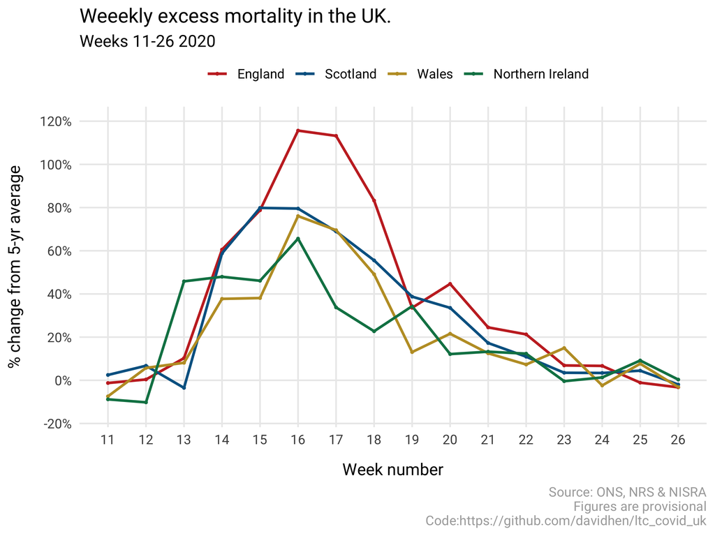

```r
fig_5 <-
  uk %>%
  group_by(country, week_number) %>%
  summarise(all = sum(all),
            average = sum(average),
            excess = all - average) %>%
  mutate(pct_change = (excess / average * 100)) %>%
  ggplot(aes(week_number, pct_change, colour = country)) +
  geom_point(size = 1.5) +
  geom_line(size = 1.5) +
  scale_colour_wsj(guide = guide_legend(keywidth = 2)) +
  scale_y_continuous(limits = c(-15, 120),
                     breaks = scales::pretty_breaks(n = 6),
                     labels = scales::percent_format(scale = 1)) +
  scale_x_continuous(breaks = scales::pretty_breaks(n = 12)) +
  theme(legend.position = "top") +
  labs(title = "Weeekly excess mortality in the UK.",
       subtitle = "Weeks 11-26 2020",
       x = "Week number",
       y = "% change from 5-yr average",
       colour = "",
       caption = "Source: ONS, NRS & NISRA\nFigures are provisional\nCode:https://github.com/davidhen/ltc_covid_uk")

fig_5
```

## Table

```r
uk %>%
  group_by(country, week_number) %>%
  summarise(all = sum(all),
            average = sum(average),
            excess = all - average) %>%
  mutate(pct_change = (excess / average * 100)) %>%
  round_df(.) %>%
  my_datatable(.)
```

|  | country | week_number | all | average | excess | pct_change |
| --- | --- | --- | --- | --- | --- | --- |
| 1 | England | 11 | 10323 | 10454 | -131 | -1.25 |
| 2 | England | 12 | 9905 | 9867 | 38 | 0.39 |
| 3 | England | 13 | 10413 | 9444 | 969 | 10.26 |
| 4 | England | 14 | 15439 | 9617 | 5822 | 60.54 |
| 5 | England | 15 | 17563 | 9825 | 7738 | 78.76 |
| 6 | England | 16 | 21157 | 9811 | 11346 | 115.65 |
| 7 | England | 17 | 20841 | 9775 | 11066 | 113.21 |
| 8 | England | 18 | 17004 | 9279 | 7725 | 83.25 |
| 9 | England | 19 | 11946 | 8943 | 3003 | 33.58 |
| 10 | England | 20 | 13783 | 9528 | 4255 | 44.66 |

[output cut: 54 more lines]

# P Score Breakdown plot

Figure 6 is a combination of 3 plots. First we show the individual plots and underlying tables

## Overall

Summarising the excess across all weeks 11-26 by nation

### Plot

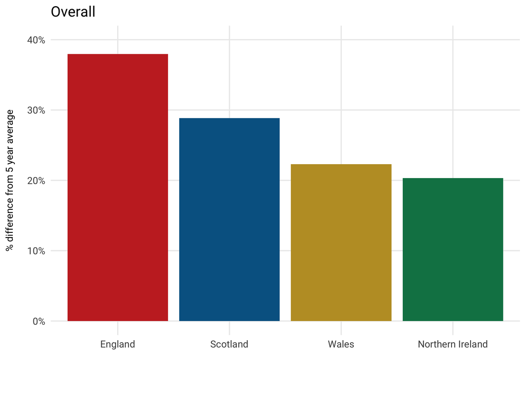

```r
uk %>%
  group_by(country) %>%
  summarise(all = sum(all),
            average = sum(average),
            excess = all - average,
            pct_change = excess / average * 100) %>%
  ggplot(aes(country, pct_change, fill = country)) +
  geom_col() +
  scale_fill_wsj() +
  scale_y_continuous(limits = c(0,40),
                     labels = scales::percent_format(scale = 1)) +
  #scale_x_discrete(position = "top") +
  theme(legend.position = "none",
        axis.title.y = element_text(size = 16)) +
  labs(title = "Overall",
       x = "",
       y = "% difference from 5 year average",
       caption = "") -> uk_excess
uk_excess
```

### Table

```r
uk %>%
  group_by(country) %>%
  summarise(all = sum(all),
            average = sum(average),
            excess = all - average) %>%
  mutate(pct_change = (excess / average * 100)) %>%
  round_df(.) %>%
  my_datatable(.)
```

|  | country | all | average | excess | pct_change |
| --- | --- | --- | --- | --- | --- |
| 1 | England | 205704 | 149119 | 56585 | 37.95 |
| 2 | Scotland | 22034 | 17101 | 4933 | 28.85 |
| 3 | Wales | 12368 | 10112 | 2256 | 22.31 |
| 4 | Northern Ireland | 5591 | 4647.2 | 943.8 | 20.31 |

## by Location only

Again a summary across all weeks 11-26 but split by location of death.

### Plot

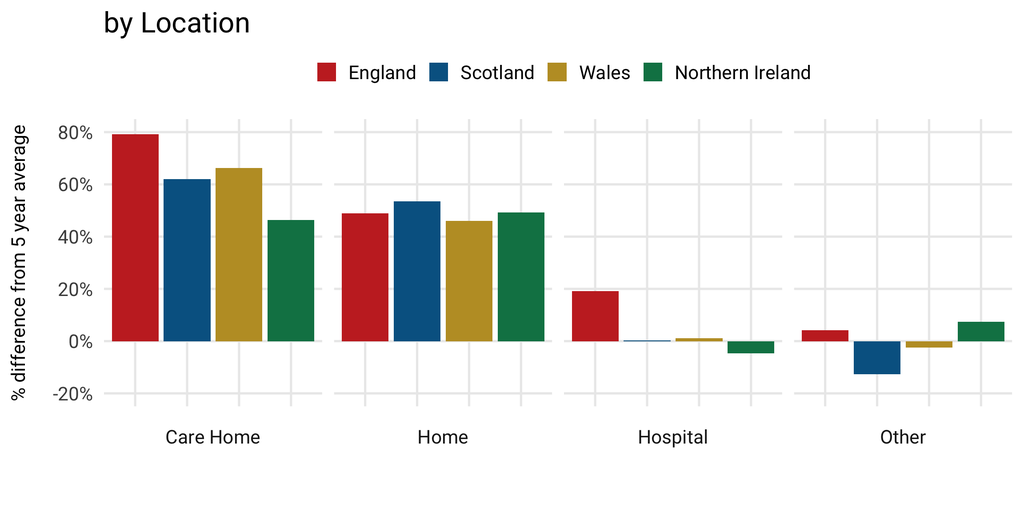

```r
fig_excess_uk_2 <-
  uk %>%
  group_by(country, location) %>%
  summarise(all = sum(all),
            average = sum(average),
            excess = all - average,
            pct_change = excess / average * 100) %>%
  ggplot(aes(country, pct_change, fill = country)) +
  geom_col() +
  facet_grid(~location, switch = "x") +
  scale_fill_wsj() +
  scale_y_continuous(limits = c(-20,80),
                     labels = scales::percent_format(scale = 1),
                     breaks = scales::pretty_breaks()) +
  theme(legend.position = "top",
        axis.text.x = element_blank(),
        strip.placement = "outside",
        axis.title.y = element_text(size = 16)) +
  labs(title = "by Location",
       x = "",
       y = "% difference from 5 year average",
       fill = "")
fig_excess_uk_2
```

### Table

```r
uk %>%
  group_by(country, location) %>%
  summarise(all = sum(all),
            covid = sum(covid),
            non_covid = sum(non_covid),
            average = sum(average),
            excess = all - average) %>%
  mutate(pct_change = (excess / average * 100)) %>%
  arrange(location) %>%
  round_df(.) %>%
  my_datatable(.)
```

|  | country | location | all | covid | non_covid | average | excess | pct_change |
| --- | --- | --- | --- | --- | --- | --- | --- | --- |
| 1 | England | Care Home | 57782 | 14120 | 43662 | 32258 | 25524 | 79.12 |
| 2 | Scotland | Care Home | 6373 | 1934 | 4439 | 3931.8 | 2441.2 | 62.09 |
| 3 | Wales | Care Home | 2695 | 678 | 2017 | 1621 | 1074 | 66.26 |
| 4 | Northern Ireland | Care Home | 1283 |  |  | 876.6 | 406.4 | 46.36 |
| 5 | England | Home | 52290 | 2124 | 50166 | 35119 | 17171 | 48.89 |
| 6 | Scotland | Home | 7118 | 289 | 6829 | 4636.4 | 2481.6 | 53.52 |
| 7 | Wales | Home | 3598 | 125 | 3473 | 2463 | 1135 | 46.08 |
| 8 | Northern Ireland | Home | 1880 |  |  | 1260.2 | 619.8 | 49.18 |
| 9 | England | Hospital | 83009 | 29829 | 53180 | 69623 | 13386 | 19.23 |
| 10 | Scotland | Hospital | 8480 | 1925 | 6555 | 8460.6 | 19.4 | 0.23 |

[output cut: 6 more lines]

## By location and week

Finally, weekly change by location and country.

### Plot

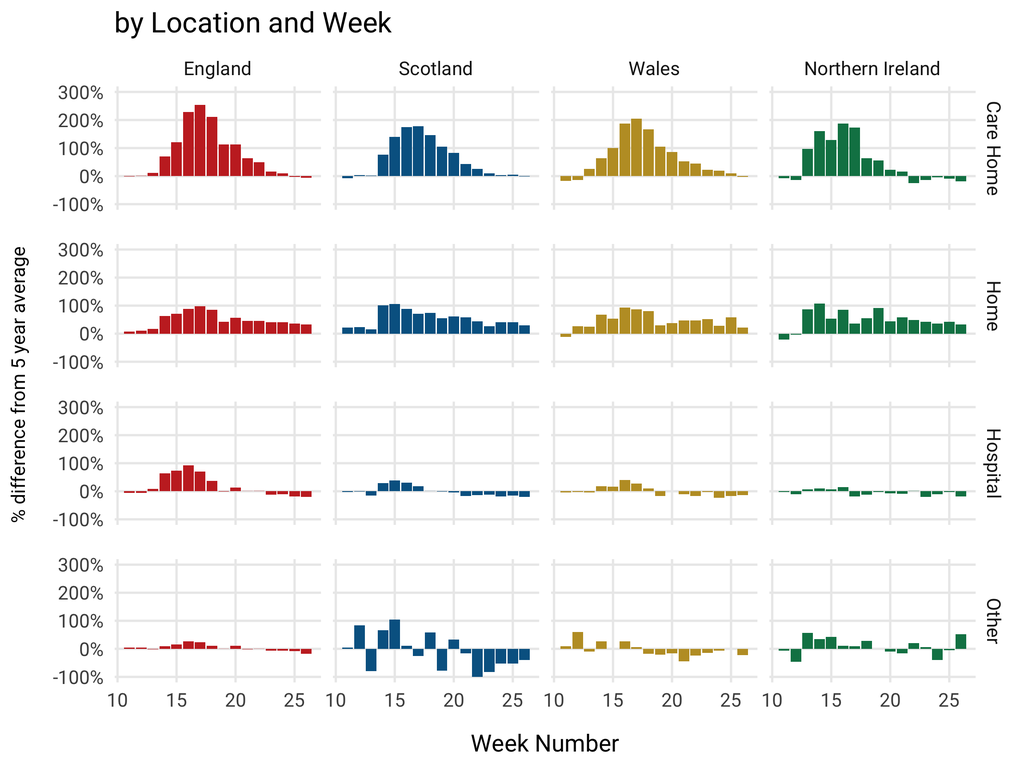

```r
fig_uk_excess_1 <-
  uk %>%
  mutate(pct_change = (excess / average * 100)) %>%
  ggplot(aes(week_number, pct_change, fill = country)) +
  geom_col() +
  facet_grid(location~country) +
  scale_fill_wsj() +
  scale_y_continuous(limits = c(-100, 300),
                     labels = scales::percent_format(scale = 1)) +
  theme(legend.position = "none",
        axis.title.y = element_text(size = 16),
        panel.spacing.y = unit(2, "lines")) +
  labs(title = "by Location and Week",
       x = "Week Number",
       y = "% difference from 5 year average")#,
       #caption = "Source: ONS & NRS\nCode:https://github.com/davidhen/ltc_covid_uk/blob/master/excess_mort_plot.Rmd")
fig_uk_excess_1
```

### Table

```r
uk %>%
  mutate(pct_change = (excess / average * 100)) %>%
  arrange(country, location, week_number) %>%
  round_df(.) %>%
  my_datatable(.)
```

|  | country | location | week_number | all | non_covid | covid | average | excess | pct_change |
| --- | --- | --- | --- | --- | --- | --- | --- | --- | --- |
| 1 | England | Care Home | 11 | 2372 | 2372 | 0 | 2409 | -37 | -1.54 |
| 2 | England | Care Home | 12 | 2236 | 2234 | 2 | 2216 | 20 | 0.9 |
| 3 | England | Care Home | 13 | 2352 | 2332 | 20 | 2113 | 239 | 11.31 |
| 4 | England | Care Home | 14 | 3592 | 3405 | 187 | 2114 | 1478 | 69.91 |
| 5 | England | Care Home | 15 | 4704 | 3936 | 768 | 2129 | 2575 | 120.95 |
| 6 | England | Care Home | 16 | 7012 | 5084 | 1928 | 2134 | 4878 | 228.58 |
| 7 | England | Care Home | 17 | 7587 | 4918 | 2669 | 2147 | 5440 | 253.38 |
| 8 | England | Care Home | 18 | 6144 | 3815 | 2329 | 1978 | 4166 | 210.62 |
| 9 | England | Care Home | 19 | 4050 | 2460 | 1590 | 1905 | 2145 | 112.6 |
| 10 | England | Care Home | 20 | 4279 | 2687 | 1592 | 2012 | 2267 | 112.67 |

[output cut: 246 more lines]

# Combination plot Figure 6

Using the `patchwork` package to combine together.

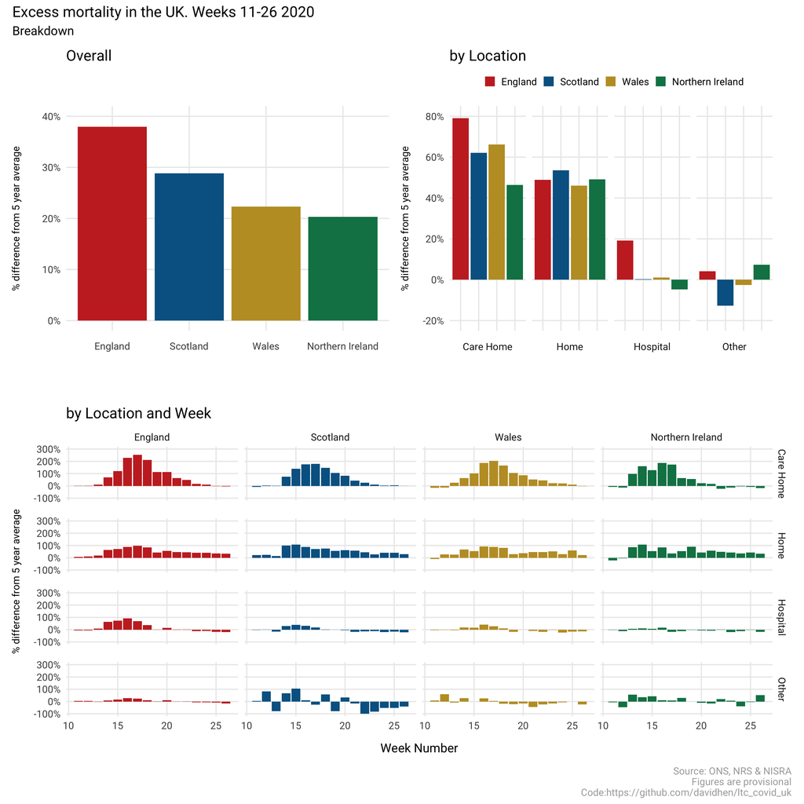

```r
(uk_excess + fig_excess_uk_2) / fig_uk_excess_1 +
  plot_annotation(title = "Excess mortality in the UK. Weeks 11-26 2020",
                  subtitle = "Breakdown",
                  caption = "Source: ONS, NRS & NISRA\nFigures are provisional\nCode:https://github.com/davidhen/ltc_covid_uk") +
  plot_layout(heights = c(1, 1.2))  -> fig_6
fig_6
```

# [HOME PAGE](https://davidhen.github.io/ltc_covid_uk/index.html)